# Melchizedek Ackah-Blay

December 11, 2024

**Human Resources Case**

*load libraries*

```python
import pandas as pd
import numpy as np
import matplotlib.pyplot as plt
import matplotlib.style as style
style.use('ggplot')
import seaborn as sns

import warnings as w
w.filterwarnings('ignore')
```

*load data*

```python
dataset = pd.read_csv(r'/Users/melki/Desktop/human_resource_data.csv')
```

*show sample data*

```python
dataset.sample(4)
```

|  | Employee_Name | EmpID | MarriedID | MaritalStatusID | GenderID | EmpStatusID | DeptID | PerfScoreID | FromDiversityJobFairID | Salary | ... | ManagerName | ManagerID | RecruitmentSource | PerformanceScore | EngagementSurvey | EmpSatisfaction | SpecialProjectsCount | LastPerformanceReview_Date | DaysLateLast30 | Absences |
| --- | --- | --- | --- | --- | --- | --- | --- | --- | --- | --- | --- | --- | --- | --- | --- | --- | --- | --- | --- | --- | --- |
| 95 | Forrest, Alex | 10305 | 1 | 1 | 1 | 1 | 6 | 3 | 0 | 70187 | ... | Lynn Daneault | 21.0 | Employee Referral | PIP | 2.00 | 5 | 0 | 1/28/2019 | 4 | 7 |
| 306 | Woodson, Jason | 10135 | 0 | 0 | 1 | 1 | 5 | 3 | 0 | 65893 | ... | Kissy Sullivan | 20.0 | LinkedIn | Fully Meets | 4.07 | 4 | 0 | 2/28/2019 | 0 | 13 |
| 112 | Gonzalez, Juan | 10300 | 1 | 1 | 1 | 5 | 5 | 1 | 1 | 68898 | ... | Brannon Miller | 12.0 | Diversity Job Fair | PIP | 3.00 | 3 | 0 | 03/06/2011 | 3 | 10 |
| 17 | Beatrice, Courtney | 10055 | 0 | 0 | 0 | 1 | 5 | 3 | 0 | 59026 | ... | Elijiah Gray | 16.0 | Google Search | Fully Meets | 5.00 | 5 | 0 | 1/14/2019 | 0 | 12 |

4 rows × 36 columns

*editing columns*

```python
dataset.columns = dataset.columns.str.lower()
```

*duplicating dataset*

```python
df = dataset.copy()
```

*data shape*

```python
df.shape
```

```
(311, 36)
```

*data information*

```python
df.info()
```

```
<class 'pandas.core.frame.DataFrame'>
RangeIndex: 311 entries, 0 to 310
Data columns (total 36 columns):
 #   Column                      Non-Null Count  Dtype
---  ------                      --------------  -----
 0   employee_name               311 non-null    object
 1   empid                       311 non-null    int64
 2   marriedid                   311 non-null    int64
 3   maritalstatusid             311 non-null    int64
 4   genderid                    311 non-null    int64
 5   empstatusid                 311 non-null    int64
 6   deptid                      311 non-null    int64
 7   perfscoreid                 311 non-null    int64
 8   fromdiversityjobfairid      311 non-null    int64
 9   salary                      311 non-null    int64
```

[output cut: 28 more lines]

*summary statistics*

```python
df.describe()
```

|  | empid | marriedid | maritalstatusid | genderid | empstatusid | deptid | perfscoreid | fromdiversityjobfairid | salary | termd | positionid | zip | managerid | engagementsurvey | empsatisfaction | specialprojectscount | dayslatelast30 | absences |
| --- | --- | --- | --- | --- | --- | --- | --- | --- | --- | --- | --- | --- | --- | --- | --- | --- | --- | --- |
| count | 311.000000 | 311.000000 | 311.000000 | 311.000000 | 311.000000 | 311.000000 | 311.000000 | 311.000000 | 311.000000 | 311.000000 | 311.000000 | 311.000000 | 303.000000 | 311.000000 | 311.000000 | 311.000000 | 311.000000 | 311.000000 |
| mean | 10156.000000 | 0.398714 | 0.810289 | 0.434084 | 2.392283 | 4.610932 | 2.977492 | 0.093248 | 69020.684887 | 0.334405 | 16.845659 | 6555.482315 | 14.570957 | 4.110000 | 3.890675 | 1.218650 | 0.414791 | 10.237942 |
| std | 89.922189 | 0.490423 | 0.943239 | 0.496435 | 1.794383 | 1.083487 | 0.587072 | 0.291248 | 25156.636930 | 0.472542 | 6.223419 | 16908.396884 | 8.078306 | 0.789938 | 0.909241 | 2.349421 | 1.294519 | 5.852596 |
| min | 10001.000000 | 0.000000 | 0.000000 | 0.000000 | 1.000000 | 1.000000 | 1.000000 | 0.000000 | 45046.000000 | 0.000000 | 1.000000 | 1013.000000 | 1.000000 | 1.120000 | 1.000000 | 0.000000 | 0.000000 | 1.000000 |
| 25% | 10078.500000 | 0.000000 | 0.000000 | 0.000000 | 1.000000 | 5.000000 | 3.000000 | 0.000000 | 55501.500000 | 0.000000 | 18.000000 | 1901.500000 | 10.000000 | 3.690000 | 3.000000 | 0.000000 | 0.000000 | 5.000000 |
| 50% | 10156.000000 | 0.000000 | 1.000000 | 0.000000 | 1.000000 | 5.000000 | 3.000000 | 0.000000 | 62810.000000 | 0.000000 | 19.000000 | 2132.000000 | 15.000000 | 4.280000 | 4.000000 | 0.000000 | 0.000000 | 10.000000 |
| 75% | 10233.500000 | 1.000000 | 1.000000 | 1.000000 | 5.000000 | 5.000000 | 3.000000 | 0.000000 | 72036.000000 | 1.000000 | 20.000000 | 2355.000000 | 19.000000 | 4.700000 | 5.000000 | 0.000000 | 0.000000 | 15.000000 |
| max | 10311.000000 | 1.000000 | 4.000000 | 1.000000 | 5.000000 | 6.000000 | 4.000000 | 1.000000 | 250000.000000 | 1.000000 | 30.000000 | 98052.000000 | 39.000000 | 5.000000 | 5.000000 | 8.000000 | 6.000000 | 20.000000 |

*null values*

```python
df.isna().sum()
```

```
employee_name                   0
empid                           0
marriedid                       0
maritalstatusid                 0
genderid                        0
empstatusid                     0
deptid                          0
perfscoreid                     0
fromdiversityjobfairid          0
salary                          0
termd                           0
positionid                      0
position                        0
state                           0
zip                             0
dob                             0
sex                             0
maritaldesc                     0
citizendesc                     0
hispaniclatino                  0
racedesc                        0
dateofhire                      0
dateoftermination             207
termreason                      0
employmentstatus                0
department                      0
managername                     0
managerid                       8
recruitmentsource               0
performancescore                0
engagementsurvey                0
empsatisfaction                 0
specialprojectscount            0
lastperformancereview_date      0
dayslatelast30                  0
absences                        0
dtype: int64
```

*duplicates*

```python
df.duplicated().sum()
```

```
0
```

*displaying all columns*

```python
pd.reset_option('display.max_columns', None)
```

*addressing dates*

```python
df['dateofhire'] = pd.to_datetime(df['dateofhire'])
df['dateoftermination'] = pd.to_datetime(df['dateoftermination'])
```

*verifying it worked*

```python
df[['dateofhire']].head(9)
```

|  | dateofhire |
| --- | --- |
| 0 | 2011-07-05 |
| 1 | 2015-03-30 |
| 2 | 2011-07-05 |
| 3 | 2008-01-07 |
| 4 | 2011-07-11 |
| 5 | 2012-01-09 |
| 6 | 2014-11-10 |
| 7 | 2013-09-30 |
| 8 | 2009-07-06 |

**finding the average salary of employees**

```python
df['salary'].mean()
```

```
69020.6848874598
```

**finding employee with highest salary**

```python
highest_salary_data = df[df['salary'] == df['salary'].max()]
highest_salary_id = pd.DataFrame(highest_salary_data[['employee_name', 'salary']])
highest_salary_id.columns = ['Employee Name', 'Salary']
highest_salary_id
```

|  | Employee Name | Salary |
| --- | --- | --- |
| 150 | King, Janet | 250000 |

**finding employee with lowest salary**

```python
lowest_salary_data = df[df['salary'] == df['salary'].min()]
lowest_salary_id = pd.DataFrame(lowest_salary_data[['employee_name', 'salary']])
lowest_salary_id.columns = ['Employee Name', 'Salary']
lowest_salary_id
```

|  | Employee Name | Salary |
| --- | --- | --- |
| 310 | Zima, Colleen | 45046 |

**finding employee(s) with most absences**

```python
absent_data = df[df['absences'] == df['absences'].max()]
absent_id = pd.DataFrame(absent_data[['employee_name', 'absences']])
absent_id.columns = ['Employee Name', 'Absences']
absent_id
```

|  | Employee Name | Absences |
| --- | --- | --- |
| 15 | Bates, Norman | 20 |
| 93 | Fitzpatrick, Michael J | 20 |
| 107 | Givens, Myriam | 20 |
| 109 | Goeth, Amon | 20 |
| 114 | Good, Susan | 20 |
| 121 | Guilianno, Mike | 20 |
| 123 | Hankard, Earnest | 20 |
| 155 | Kreuger, Freddy | 20 |
| 158 | Langford, Lindsey | 20 |
| 161 | Latif, Mohammed | 20 |
| 164 | LeBlanc, Brandon R | 20 |
| 183 | Mckenna, Sandy | 20 |
| 256 | Sloan, Constance | 20 |
| 263 | Sparks, Taylor | 20 |

**most-tenured employees at the company**

```python
df['hire_year'] = df['dateofhire'].dt.year
tenured = df[['employee_name', 'hire_year']]
tenured.rename(columns = {'employee_name':'Employee Name', 'hire_year':'Hire Year'}, inplace = True)
tenured.sort_values(by = 'Hire Year').head(10)
```

|  | Employee Name | Hire Year |
| --- | --- | --- |
| 282 | Torrence, Jack | 2006 |
| 280 | Thibaud, Kenneth | 2007 |
| 222 | Pitt, Brad | 2007 |
| 307 | Ybarra, Catherine | 2008 |
| 3 | Alagbe,Trina | 2008 |
| 29 | Brown, Mia | 2008 |
| 8 | Bachiochi, Linda | 2009 |
| 256 | Sloan, Constance | 2009 |
| 247 | Sadki, Nore | 2009 |
| 276 | Tavares, Desiree | 2009 |

```python
df['termination_year'] = df['dateoftermination'].dt.year
```

*creating more date time variables*

```python
df['hire_month'] = df['dateofhire'].dt.month_name()
df['termination_month'] = df['dateoftermination'].dt.month_name()

df['hire_day'] = df['dateofhire'].dt.day_name()
df['termination_day'] = df['dateoftermination'].dt.day_name()
```

**employee who has been the most late in the past 30 days**

```python
last_30 = df[df['dayslatelast30'] == df['dayslatelast30'].max()]
```

```python
last_30_id = pd.DataFrame(last_30[['employee_name', 'dayslatelast30']])
last_30_id.columns = ['Employee Name', 'Days Late In The Past Month']
last_30_id
```

|  | Employee Name | Days Late In The Past Month |
| --- | --- | --- |
| 67 | Delarge, Alex | 6 |
| 90 | Fernandes, Nilson | 6 |
| 188 | Miller, Ned | 6 |
| 205 | O'hare, Lynn | 6 |
| 263 | Sparks, Taylor | 6 |
| 297 | Wallace, Theresa | 6 |

**most popular year to get hired**

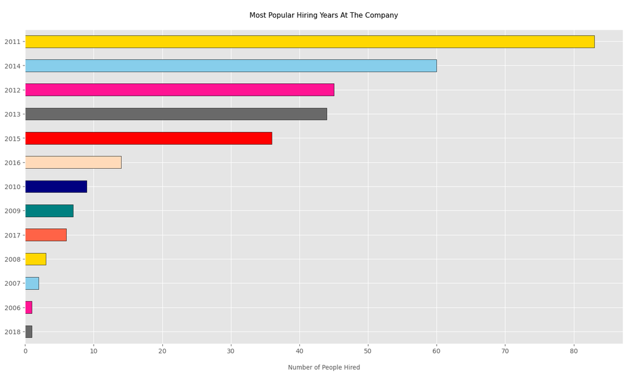

```python
popular_hr_date = df['hire_year'].value_counts(ascending = True)
plt.figure(figsize = (17, 9))
popular_hr_date.plot(kind = 'barh', edgecolor = 'black', color = ['dimgray', 'deeppink', 'skyblue', 'gold', 'tomato', 'teal', 'navy', 'peachpuff','red'])
plt.title('\nMost Popular Hiring Years At The Company\n', fontsize = 11)
plt.ylabel('')
plt.xlabel('\nNumber of People Hired', fontsize = 9.5)
plt.show()
```

**most popular month to get hired**

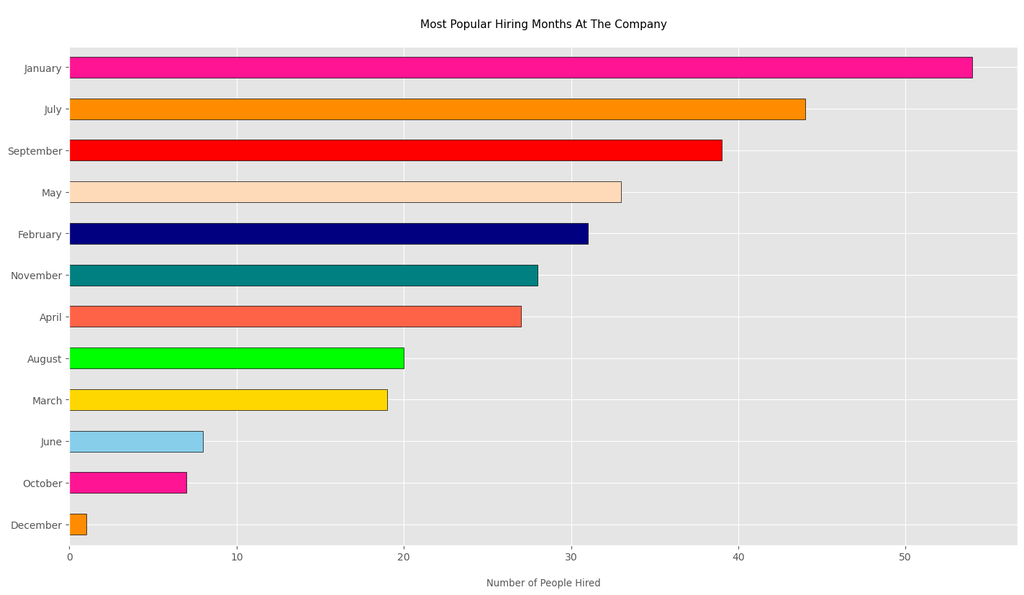

```python
popular_hr_month = df['hire_month'].value_counts(ascending = True)
plt.figure(figsize = (17, 9))
popular_hr_month.plot(kind = 'barh', edgecolor = 'black', color = ['darkorange', 'deeppink', 'skyblue', 'gold', 'lime', 'tomato', 'teal', 'navy', 'peachpuff','red'])
plt.title('\nMost Popular Hiring Months At The Company\n', fontsize = 11)
plt.ylabel('')
plt.xlabel('\nNumber of People Hired', fontsize = 9.5)
plt.show()
```

**most popular day to get hired**

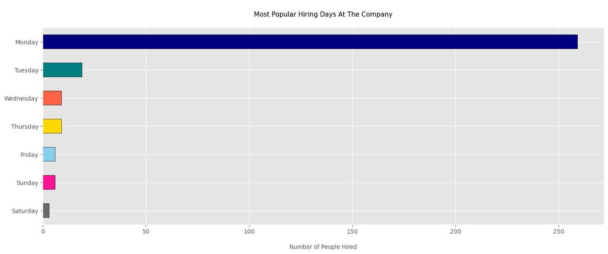

```python
popular_hr_day = df['hire_day'].value_counts(ascending = True)
plt.figure(figsize = (17, 6))
popular_hr_day.plot(kind = 'barh', edgecolor = 'black', color = ['dimgray', 'deeppink', 'skyblue', 'gold', 'tomato', 'teal', 'navy', 'peachpuff','red'])
plt.title('\nMost Popular Hiring Days At The Company\n', fontsize = 11)
plt.ylabel('')
plt.xlabel('\nNumber of People Hired', fontsize = 9.5)
plt.show()
```

**most popular years to get terminated**

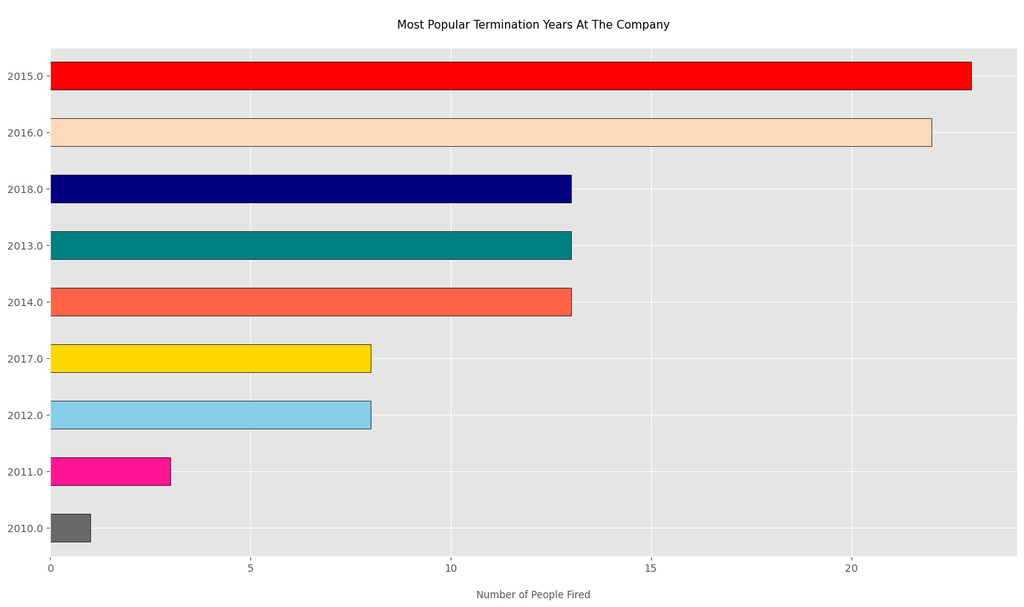

```python
popular_tr_years = df['termination_year'].value_counts(ascending = True)
plt.figure(figsize = (17, 9))
popular_tr_years.plot(kind = 'barh', edgecolor = 'black', color = ['dimgray', 'deeppink', 'skyblue', 'gold', 'tomato', 'teal', 'navy', 'peachpuff','red'])
plt.title('\nMost Popular Termination Years At The Company\n', fontsize = 11)
plt.ylabel('')
plt.xlabel('\nNumber of People Fired', fontsize = 9.5)
plt.show()
```

**most popular months to get terminated**

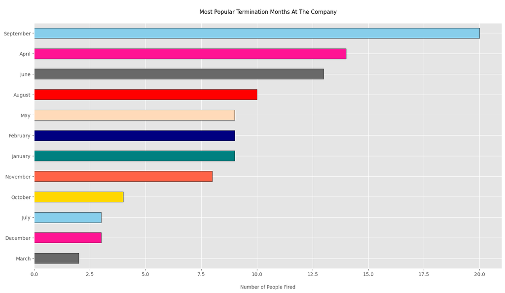

```python
popular_tr_months = df['termination_month'].value_counts(ascending = True)
plt.figure(figsize = (17, 9))
popular_tr_months.plot(kind = 'barh', edgecolor = 'black', color = ['dimgray', 'deeppink', 'skyblue', 'gold', 'tomato', 'teal', 'navy', 'peachpuff','red'])
plt.title('\nMost Popular Termination Months At The Company\n', fontsize = 11)
plt.ylabel('')
plt.xlabel('\nNumber of People Fired', fontsize = 9.5)
plt.show()
```

**most popular days to get terminated**

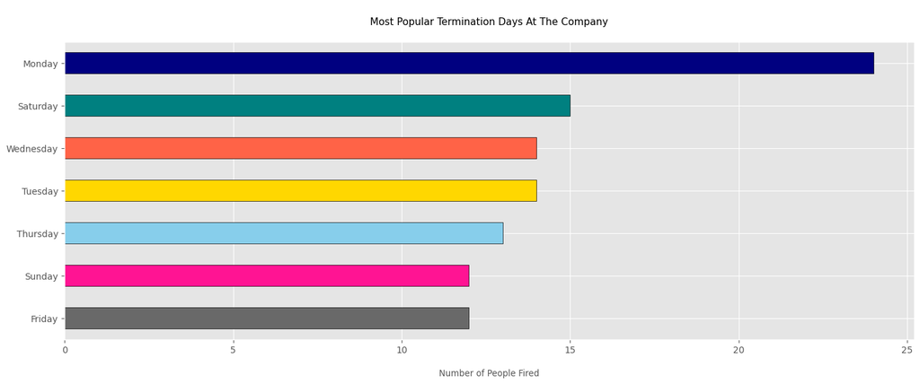

```python
popular_tr_days = df['termination_day'].value_counts(ascending = True)
plt.figure(figsize = (17, 6))
popular_tr_days.plot(kind = 'barh', edgecolor = 'black', color = ['dimgray', 'deeppink', 'skyblue', 'gold', 'tomato', 'teal', 'navy', 'peachpuff','red'])
plt.title('\nMost Popular Termination Days At The Company\n', fontsize = 11)
plt.ylabel('')
plt.xlabel('\nNumber of People Fired', fontsize = 9.5)
plt.show()
```

**salary distribution**

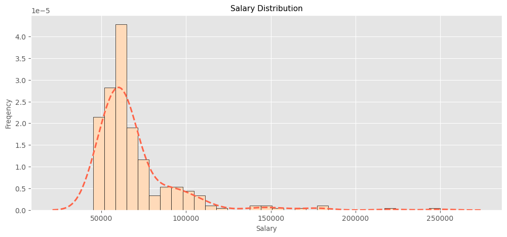

```python
plt.figure(figsize = (12, 5))
plt.hist(df['salary'], edgecolor = 'black', color = 'peachpuff', density = True, bins = 31)
sns.kdeplot(df['salary'], color = 'tomato', linewidth = 2.2, linestyle = '--')
plt.title('Salary Distribution', fontsize = 11)
plt.xlabel('Salary', fontsize = 9.5)
plt.ylabel('Freqency', fontsize = 9.5)
plt.show()
```

**positions at the company**

```python
positions_count = df['position'].value_counts(ascending = False)
pd.DataFrame(positions_count)
```

| position | count |
| --- | --- |
| Production Technician I | 137 |
| Production Technician II | 57 |
| Area Sales Manager | 27 |
| Production Manager | 14 |
| Software Engineer | 10 |
| IT Support | 8 |
| Data Analyst | 7 |
| Sr. Network Engineer | 5 |
| Database Administrator | 5 |
| Network Engineer | 5 |
| BI Developer | 4 |
| Senior BI Developer | 3 |
| Administrative Assistant | 3 |
| Sales Manager | 3 |
| Accountant I | 3 |
| Sr. DBA | 2 |
| IT Manager - DB | 2 |
| Sr. Accountant | 2 |
| Director of Operations | 1 |
| Shared Services Manager | 1 |
| Data Analyst | 1 |
| Data Architect | 1 |
| Principal Data Architect | 1 |
| IT Manager - Infra | 1 |
| President & CEO | 1 |
| Enterprise Architect | 1 |
| BI Director | 1 |
| Director of Sales | 1 |
| IT Director | 1 |
| IT Manager - Support | 1 |
| Software Engineering Manager | 1 |
| CIO | 1 |

**most popular positions at the company**

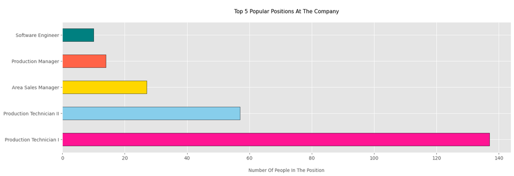

```python
plt.figure(figsize = (17, 5))
positions_count.head(5).plot(kind = 'barh', edgecolor = 'black', color = ['deeppink', 'skyblue', 'gold', 'tomato', 'teal', 'navy', 'peachpuff','red'])
plt.title('\nTop 5 Popular Positions At The Company\n', fontsize = 11)
plt.xlabel('\nNumber Of People In The Position', fontsize = 9.5)
plt.ylabel('')
plt.show()
```

**least popular positions at the company**

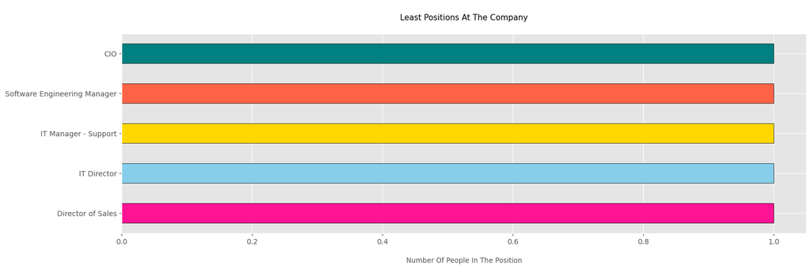

```python
plt.figure(figsize = (17, 5))
positions_count.tail(5).plot(kind = 'barh', edgecolor = 'black', color = ['deeppink', 'skyblue', 'gold', 'tomato', 'teal', 'navy', 'peachpuff','red'])
plt.title('\nLeast Positions At The Company\n', fontsize = 11)
plt.xlabel('\nNumber Of People In The Position', fontsize = 9.5)
plt.ylabel('')
plt.show()
```

**state representation at the company**

```python
state_repr = df['state'].value_counts(ascending = False)
pd.DataFrame(state_repr)
```

| state | count |
| --- | --- |
| MA | 276 |
| CT | 6 |
| TX | 3 |
| VT | 2 |
| UT | 1 |
| AZ | 1 |
| ND | 1 |
| OR | 1 |
| MT | 1 |
| NV | 1 |
| ID | 1 |
| KY | 1 |
| NC | 1 |
| FL | 1 |
| GA | 1 |
| CO | 1 |
| NY | 1 |
| PA | 1 |
| RI | 1 |
| NH | 1 |
| TN | 1 |
| IN | 1 |
| OH | 1 |
| CA | 1 |
| WA | 1 |
| AL | 1 |
| VA | 1 |
| ME | 1 |

**most represented states at the company**

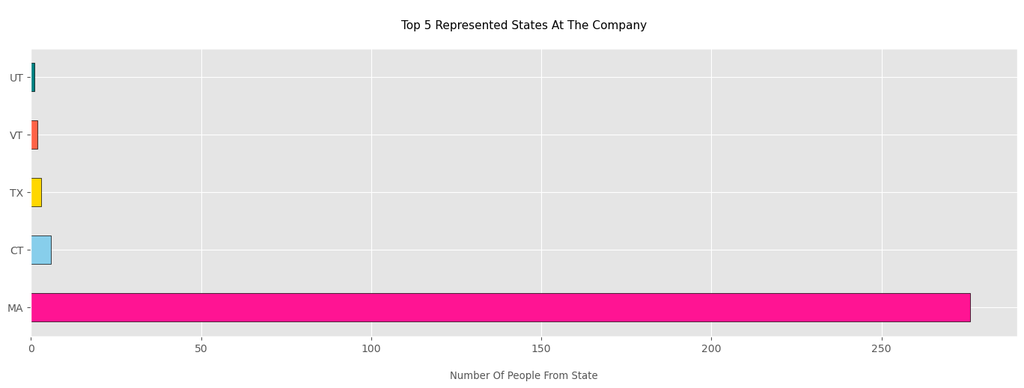

```python
plt.figure(figsize = (17, 5))
state_repr.head(5).plot(kind = 'barh', edgecolor = 'black', color = ['deeppink', 'skyblue', 'gold', 'tomato', 'teal', 'navy', 'peachpuff','red'])
plt.title('\nTop 5 Represented States At The Company\n', fontsize = 11)
plt.xlabel('\nNumber Of People From State', fontsize = 9.5)
plt.ylabel('')
plt.show()
```

**most represented zipcodes at the company**

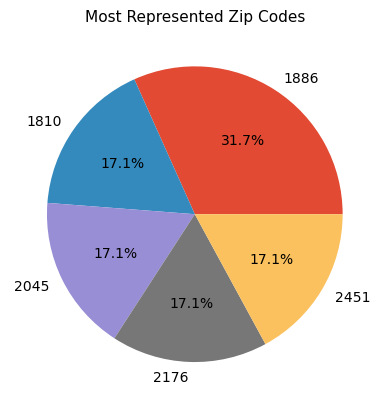

```python
repr_zipcodes = df['zip'].value_counts(ascending = False)
repr_zipcodes.head(5).plot(kind = 'pie', autopct = '%1.1f%%')
plt.title('Most Represented Zip Codes', fontsize = 11)
plt.xlabel('')
plt.ylabel('')
plt.show()
```

*making birthday datetime*

```python
df['dob'] = pd.to_datetime(df['dob'],  format='%m/%d/%y', errors='coerce')

df['birth_year'] = df['dob'].dt.year
df['birth_month'] = df['dob'].dt.month_name()
df['birth_day'] = df['dob'].dt.day_name()
```

**most popular employee birth years**

```python
pd.DataFrame(df['birth_year'].value_counts(ascending = False).head(5))
```

| birth_year | count |
| --- | --- |
| 1987.0 | 14 |
| 1979.0 | 12 |
| 1983.0 | 11 |
| 1988.0 | 10 |
| 1985.0 | 9 |

**oldest employees at the company**

```python
oldest_employees = df[df['birth_year'] == df['birth_year'].min()]
oldest_employees_id = pd.DataFrame(oldest_employees[['employee_name', 'birth_year']])
oldest_employees_id.columns = ['Employee Name', 'Birth Year']
oldest_employees_id
```

|  | Employee Name | Birth Year |
| --- | --- | --- |
| 31 | Bugali, Josephine | 1969.0 |
| 111 | Gonzalez, Cayo | 1969.0 |
| 155 | Kreuger, Freddy | 1969.0 |
| 287 | Turpin, Jumil | 1969.0 |

**most popular employee birth months**

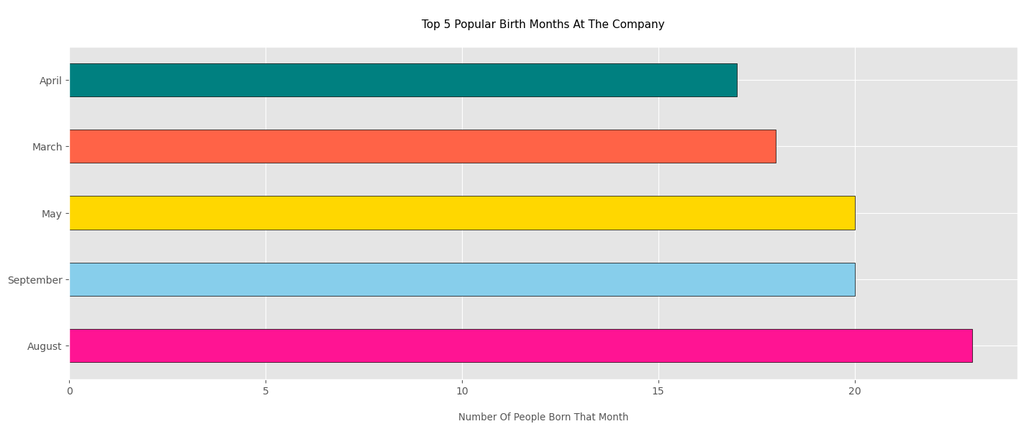

```python
month_representation = df['birth_month'].value_counts(ascending = False)

plt.figure(figsize = (17, 6))
month_representation.head(5).plot(kind = 'barh', edgecolor = 'black', color = ['deeppink', 'skyblue', 'gold', 'tomato', 'teal', 'navy', 'peachpuff','red'])
plt.title('\nTop 5 Popular Birth Months At The Company\n', fontsize = 11)
plt.xlabel('\nNumber Of People Born That Month', fontsize = 9.5)
plt.ylabel('')
plt.show()
```

**most popular employee birth days**

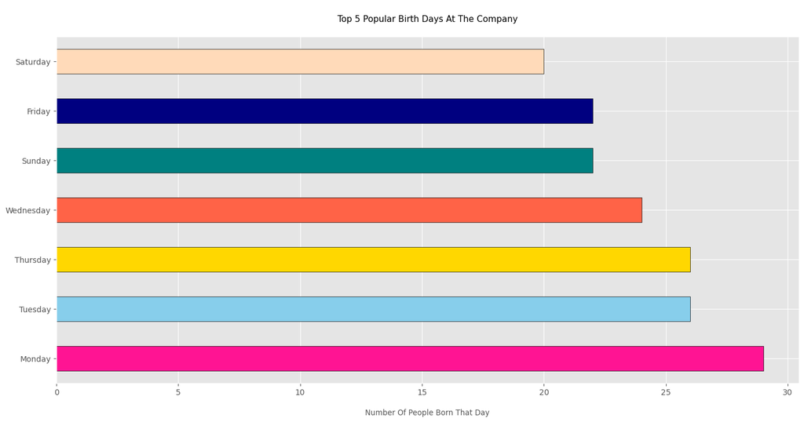

```python
day_representation = df['birth_day'].value_counts(ascending = False)

plt.figure(figsize = (17, 8))
day_representation.plot(kind = 'barh', edgecolor = 'black', color = ['deeppink', 'skyblue', 'gold', 'tomato', 'teal', 'navy', 'peachpuff','red'])
plt.title('\nTop 5 Popular Birth Days At The Company\n', fontsize = 11)
plt.xlabel('\nNumber Of People Born That Day', fontsize = 9.5)
plt.ylabel('')
plt.show()
```

**employee gender distribution**

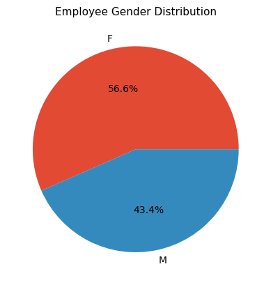

```python
gender_dist = df['sex'].value_counts()
gender_dist.plot(kind = 'pie', autopct = '%1.1f%%')
plt.title('Employee Gender Distribution', fontsize = 11)
plt.xlabel('')
plt.ylabel('')
plt.show()
```

**Employee Marital Status Distribution**

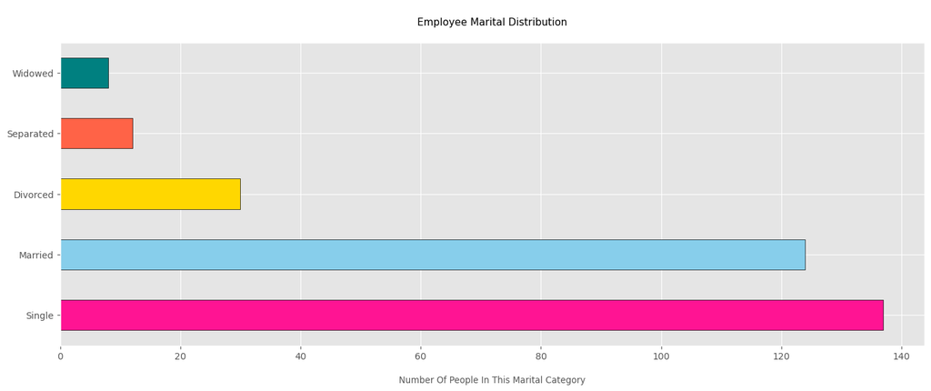

```python
martital_dist = df['maritaldesc'].value_counts(ascending = False)

plt.figure(figsize = (17, 6))
martital_dist.plot(kind = 'barh', edgecolor = 'black', color = ['deeppink', 'skyblue', 'gold', 'tomato', 'teal', 'navy', 'peachpuff','red'])
plt.title('\nEmployee Marital Distribution\n', fontsize = 11)
plt.xlabel('\nNumber Of People In This Marital Category', fontsize = 9.5)
plt.ylabel('')
plt.show()
```

**Employee Citizenship Status Distribution**

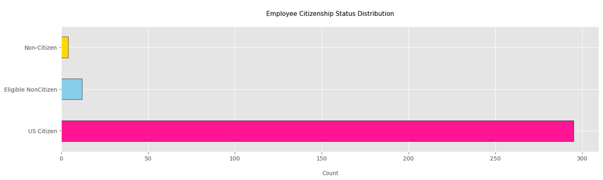

```python
citizen_dist = df['citizendesc'].value_counts(ascending = False)

plt.figure(figsize = (17, 4))
citizen_dist.plot(kind = 'barh', edgecolor = 'black', color = ['deeppink', 'skyblue', 'gold', 'tomato', 'teal', 'navy', 'peachpuff','red'])
plt.title('\nEmployee Citizenship Status Distribution\n', fontsize = 11)
plt.xlabel('\nCount', fontsize = 9.5)
plt.ylabel('')
plt.show()
```

**Employee Racial Distribution**

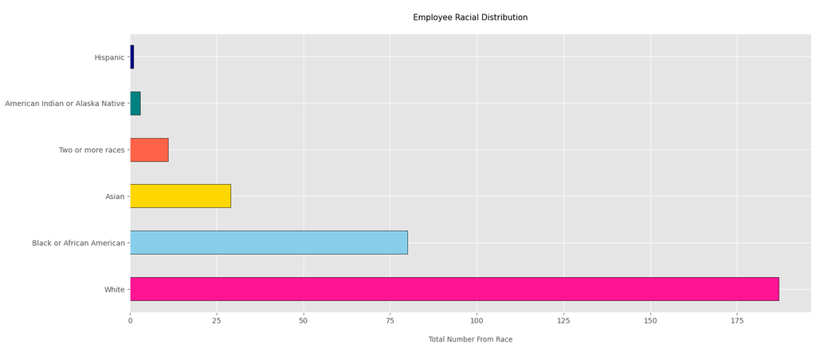

```python
race_dist = df['racedesc'].value_counts(ascending = False)

plt.figure(figsize = (17, 7))
race_dist.plot(kind = 'barh', edgecolor = 'black', color = ['deeppink', 'skyblue', 'gold', 'tomato', 'teal', 'navy', 'peachpuff','red'])
plt.title('\nEmployee Racial Distribution\n', fontsize = 11)
plt.xlabel('\nTotal Number From Race', fontsize = 9.5)
plt.ylabel('')
plt.show()
```

**Most Popular Reasons For Terminating Employees**

```python
term_reason = df['termreason'].value_counts(ascending = False)
term_plot = term_reason.iloc[2:]
pd.DataFrame(term_plot)
```

| termreason | count |
| --- | --- |
| unhappy | 14 |
| more money | 11 |
| career change | 9 |
| hours | 8 |
| attendance | 7 |
| return to school | 5 |
| relocation out of area | 5 |
| no-call, no-show | 4 |
| military | 4 |
| retiring | 4 |
| performance | 4 |
| maternity leave - did not return | 3 |
| medical issues | 3 |
| Learned that he is a gangster | 1 |
| Fatal attraction | 1 |
| gross misconduct | 1 |

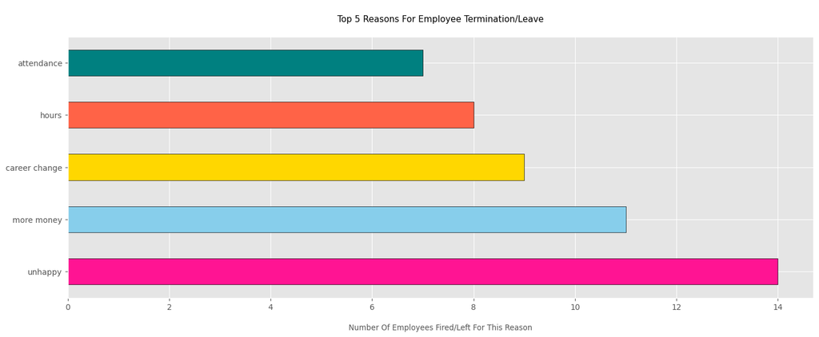

```python
plt.figure(figsize = (17, 6))
term_plot.head(5).plot(kind = 'barh', edgecolor = 'black', color = ['deeppink', 'skyblue', 'gold', 'tomato', 'teal', 'navy', 'peachpuff','red'])
plt.title('\nTop 5 Reasons For Employee Termination/Leave\n', fontsize = 11)
plt.xlabel('\nNumber Of Employees Fired/Left For This Reason', fontsize = 9.5)
plt.ylabel('')
plt.show()
```

**Employee Employment Status Distribution**

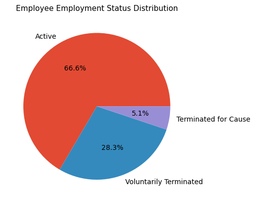

```python
empl_status = df['employmentstatus'].value_counts(ascending = False)
empl_status.plot(kind = 'pie', autopct = '%1.1f%%')
plt.title('Employee Employment Status Distribution', fontsize = 11)
plt.xlabel('')
plt.ylabel('')
plt.show()
```

**Employee Department Distribution**

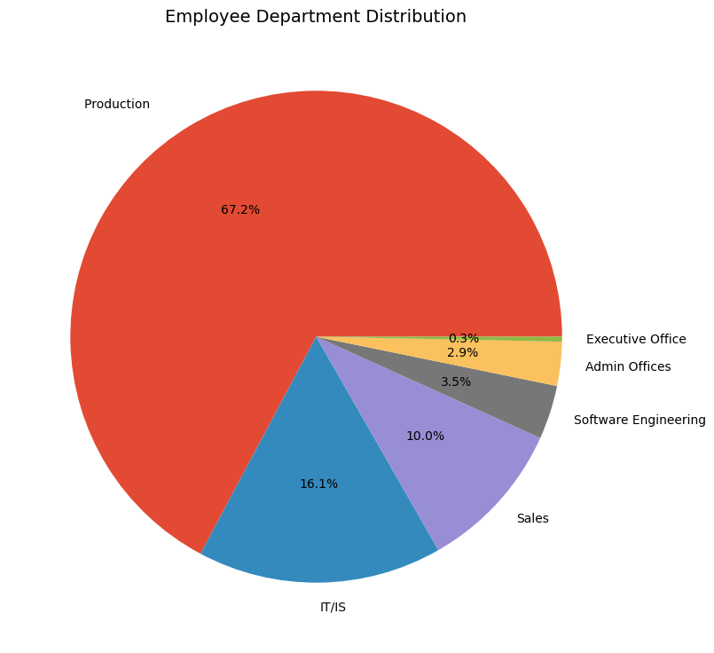

```python
dept_dist = df['department'].value_counts(ascending = False)
plt.figure(figsize = (9, 9))
dept_dist.plot(kind = 'pie', autopct = '%1.1f%%')
plt.title('Employee Department Distribution', fontsize = 14)
plt.xlabel('')
plt.ylabel('')
plt.show()
```

**Most Influential Managers**

```python
infl_mng = df['managername'].value_counts(ascending = False).head(5)
a = pd.DataFrame(infl_mng)
a.columns = ['Number Of Supervisees']
a
```

| managername | Number Of Supervisees |
| --- | --- |
| Michael Albert | 22 |
| Kissy Sullivan | 22 |
| Elijiah Gray | 22 |
| Kelley Spirea | 22 |
| Brannon Miller | 22 |

**Recruitement Souces Distribution**

```python
recmt_dist = df['recruitmentsource'].value_counts(ascending = False)
a = pd.DataFrame(recmt_dist)
a.columns = ['Number Of Employees Recruited']
a
```

| recruitmentsource | Number Of Employees Recruited |
| --- | --- |
| Indeed | 87 |
| LinkedIn | 76 |
| Google Search | 49 |
| Employee Referral | 31 |
| Diversity Job Fair | 29 |
| CareerBuilder | 23 |
| Website | 13 |
| Other | 2 |
| On-line Web application | 1 |

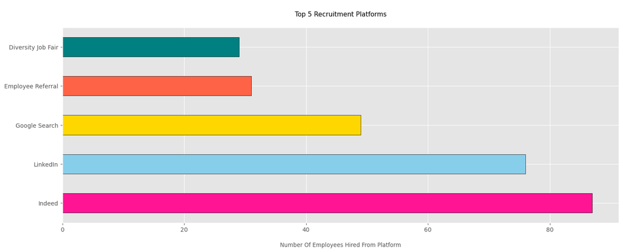

```python
plt.figure(figsize = (17, 6))
recmt_dist.head(5).plot(kind = 'barh', edgecolor = 'black', color = ['deeppink', 'skyblue', 'gold', 'tomato', 'teal', 'navy', 'peachpuff','red'])
plt.title('\nTop 5 Recruitment Platforms\n', fontsize = 11)
plt.xlabel('\nNumber Of Employees Hired From Platform', fontsize = 9.5)
plt.ylabel('')
plt.show()
```

**Employees That Exceed Performance**

```python
perf_scre = df[df['performancescore'] == 'Exceeds']
perf_scre_id = pd.DataFrame(perf_scre[['employee_name','performancescore']])
perf_scre_id.columns = ['Employee Name', 'Exceptional Performance Proof']
len_perf_scre_id = len(perf_scre_id)
perf_scre_id
```

|  | Employee Name | Exceptional Performance Proof |
| --- | --- | --- |
| 0 | Adinolfi, Wilson K | Exceeds |
| 5 | Anderson, Linda | Exceeds |
| 12 | Barbossa, Hector | Exceeds |
| 16 | Beak, Kimberly | Exceeds |
| 22 | Billis, Helen | Exceeds |
| 36 | Candie, Calvin | Exceeds |
| 51 | Clukey, Elijian | Exceeds |
| 55 | Corleone, Vito | Exceeds |
| 76 | Dougall, Eric | Exceeds |
| 77 | Driver, Elle | Exceeds |
| 96 | Foss, Jason | Exceeds |
| 106 | Girifalco, Evelyn | Exceeds |
| 111 | Gonzalez, Cayo | Exceeds |
| 125 | Harrison, Kara | Exceeds |
| 141 | Jeannite, Tayana | Exceeds |
| 143 | Johnson, George | Exceeds |
| 145 | Johnston, Yen | Exceeds |
| 167 | Liebig, Ketsia | Exceeds |
| 170 | Lindsay, Leonara | Exceeds |
| 172 | Lunquist, Lisa | Exceeds |
| 174 | Lynch, Lindsay | Exceeds |
| 191 | Monterro, Luisa | Exceeds |
| 201 | Ngodup, Shari | Exceeds |
| 208 | Osturnka, Adeel | Exceeds |
| 212 | Patronick, Lucas | Exceeds |
| 217 | Peters, Lauren | Exceeds |
| 220 | Petrowsky, Thelma | Exceeds |
| 232 | Rivera, Haley | Exceeds |
| 237 | Robinson, Elias | Exceeds |
| 257 | Smith, Joe | Exceeds |
| 265 | Squatrito, Kristen | Exceeds |
| 274 | Szabo, Andrew | Exceeds |
| 282 | Torrence, Jack | Exceeds |
| 289 | Veera, Abdellah | Exceeds |
| 293 | Volk, Colleen | Exceeds |
| 304 | Winthrop, Jordan | Exceeds |
| 308 | Zamora, Jennifer | Exceeds |

**37** out of the **311** employees **exceeded performance**

**Employee Engagement Survery Statistics**

```python
df['engagementsurvey'].describe()
```

```
count    311.000000
mean       4.110000
std        0.789938
min        1.120000
25%        3.690000
50%        4.280000
75%        4.700000
max        5.000000
Name: engagementsurvey, dtype: float64
```

The average employee engagement survey score is **4.11**

The highest employee engagement survey score is **5.0**

The lowest employee engagement survey score is **1.12**

**Employee Engagement Survey Scores Distribution**

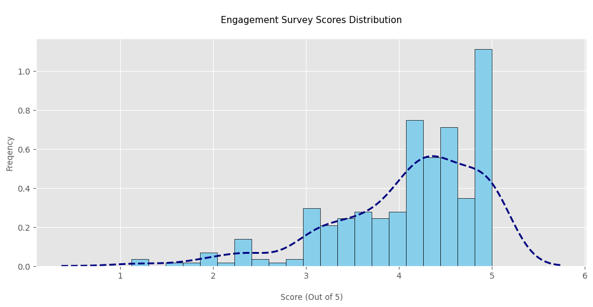

```python
plt.figure(figsize = (12, 5))
plt.hist(df['engagementsurvey'], edgecolor = 'black', color = 'skyblue', density = True, bins = 21)
sns.kdeplot(df['engagementsurvey'], color = 'navy', linewidth = 2.2, linestyle = '--')
plt.title('\nEngagement Survey Scores Distribution\n', fontsize = 11)
plt.xlabel('\nScore (Out of 5)', fontsize = 9.5)
plt.ylabel('Freqency', fontsize = 9.5)
plt.show()
```

**Employee Satisfaction Score Statistics**

```python
df['empsatisfaction'].describe()
```

```
count    311.000000
mean       3.890675
std        0.909241
min        1.000000
25%        3.000000
50%        4.000000
75%        5.000000
max        5.000000
Name: empsatisfaction, dtype: float64
```

The average employee satisfaction score is **3.89**

The highest employee satisfaction score is **5.0**

The lowest employee satisfaction score is **1.0**

**Employee Satisfaction Scores Distribution**

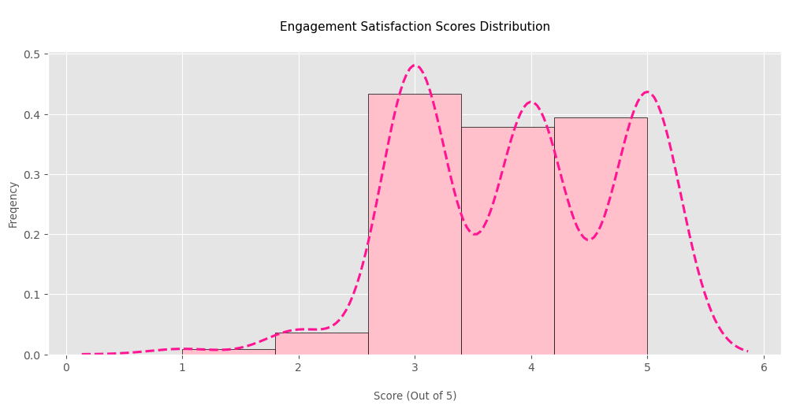

```python
plt.figure(figsize = (12, 5))
plt.hist(df['empsatisfaction'], edgecolor = 'black', color = 'pink', density = True, bins = 5)
sns.kdeplot(df['empsatisfaction'], color = 'deeppink', linewidth = 2.2, linestyle = '--')
plt.title('\nEngagement Satisfaction Scores Distribution\n', fontsize = 11)
plt.xlabel('\nScore (Out of 5)', fontsize = 9.5)
plt.ylabel('Freqency', fontsize = 9.5)
plt.show()
```

**Special Projects Distribution**

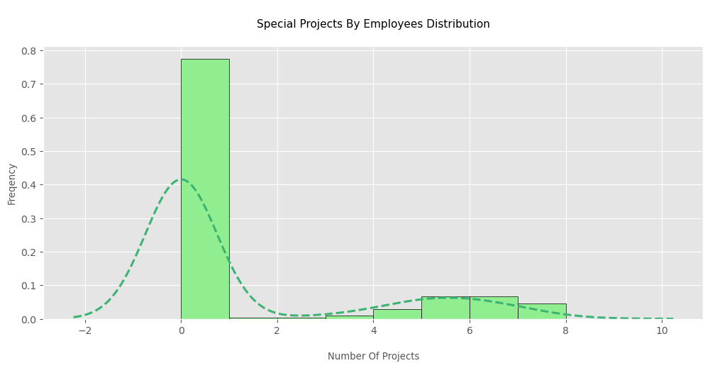

```python
plt.figure(figsize = (12, 5))
plt.hist(df['specialprojectscount'], edgecolor = 'black', color = 'lightgreen', density = True, bins = 8)
sns.kdeplot(df['specialprojectscount'], color = 'mediumseagreen', linewidth = 2.2, linestyle = '--')
plt.title('\nSpecial Projects By Employees Distribution\n', fontsize = 11)
plt.xlabel('\nNumber Of Projects', fontsize = 9.5)
plt.ylabel('Freqency', fontsize = 9.5)
plt.show()
```

## Salary Analysis

1. What is the average salary by department?

```python
a = pd.DataFrame(df.groupby('department')['salary'].mean().sort_values(ascending = False))
a.columns = ['Average Salary']
a
```

| department | Average Salary |
| --- | --- |
| Executive Office | 250000.000000 |
| IT/IS | 97064.640000 |
| Software Engineering | 94989.454545 |
| Admin Offices | 71791.888889 |
| Sales | 69061.258065 |
| Production | 59953.545455 |

2. What is the maximum salary for each position?

```python
a = pd.DataFrame(df.groupby('position')['salary'].max().sort_values(ascending = False))
a.columns = ['Maximum Salary']
a
```

| position | Maximum Salary |
| --- | --- |
| President & CEO | 250000 |
| CIO | 220450 |
| Director of Sales | 180000 |
| IT Director | 178000 |
| Director of Operations | 170500 |
| IT Manager - Infra | 157000 |
| Data Architect | 150290 |
| IT Manager - DB | 148999 |
| IT Manager - Support | 138888 |
| Principal Data Architect | 120000 |
| Database Administrator | 114800 |
| BI Director | 110929 |
| Software Engineer | 108987 |
| Sr. Network Engineer | 107226 |
| Sr. Accountant | 106367 |
| Sr. DBA | 104437 |
| Enterprise Architect | 103613 |
| BI Developer | 99020 |
| Data Analyst | 93554 |
| Shared Services Manager | 93046 |
| Production Manager | 88976 |
| Data Analyst | 88527 |
| Senior BI Developer | 87921 |
| Software Engineering Manager | 77692 |
| Network Engineer | 76029 |
| Production Technician II | 74813 |
| IT Support | 74679 |
| Area Sales Manager | 74326 |
| Sales Manager | 72992 |
| Production Technician I | 64991 |
| Accountant I | 64520 |
| Administrative Assistant | 55000 |

3. What is the minimum salary by state?

```python
a = pd.DataFrame(df.groupby('state')['salary'].min().sort_values(ascending = False))
a.columns = ['Minimum Salary']
a
```

| state | Minimum Salary |
| --- | --- |
| RI | 180000 |
| VA | 74326 |
| CA | 74241 |
| TN | 71707 |
| NY | 71339 |
| NH | 70545 |
| UT | 70468 |
| PA | 68999 |
| NC | 68829 |
| VT | 65729 |
| CO | 65310 |
| ND | 64397 |
| GA | 63695 |
| TX | 63291 |
| FL | 63051 |
| KY | 61844 |
| ID | 61809 |
| AL | 61568 |
| IN | 61555 |
| MT | 60120 |
| OH | 59370 |
| WA | 59231 |
| OR | 58370 |
| NV | 58273 |
| AZ | 57859 |
| ME | 55875 |
| CT | 51777 |
| MA | 45046 |

4. How does the median salary vary by employment status?

```python
a = pd.DataFrame(df.groupby('employmentstatus')['salary'].median().sort_values(ascending = False))
a.columns = ['Median Salary']
a
```

| employmentstatus | Median Salary |
| --- | --- |
| Active | 63051.0 |
| Terminated for Cause | 60881.0 |
| Voluntarily Terminated | 60512.0 |

5. What is the total salary cost by department?

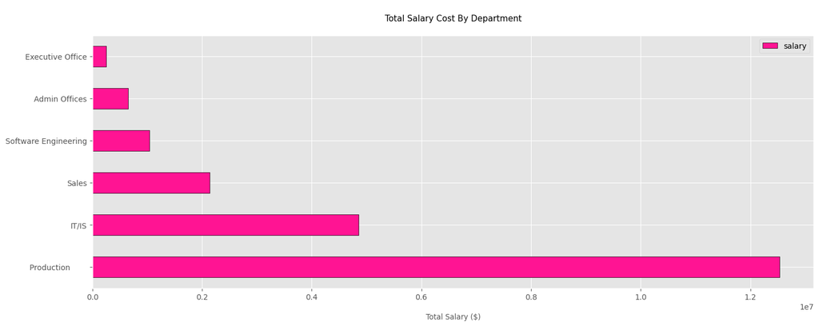

```python
a = pd.DataFrame(df.groupby('department')['salary'].sum().sort_values(ascending = False))
a.plot(kind = 'barh', edgecolor = 'black', color = ['deeppink', 'skyblue', 'gold', 'tomato', 'teal', 'navy', 'peachpuff','red'], figsize = (17, 6))
plt.title('\nTotal Salary Cost By Department\n', fontsize = 11)
plt.xlabel('\nTotal Salary ($)', fontsize = 9.5)
plt.ylabel('')
plt.show()
```

6. What is the average salary by recruitment source?

```python
a = pd.DataFrame(df.groupby('recruitmentsource')['salary'].mean().sort_values(ascending = False))
a.columns = ['Average Salary']
a
```

| recruitmentsource | Average Salary |
| --- | --- |
| Other | 83263.500000 |
| Employee Referral | 77862.838710 |
| Indeed | 75495.747126 |
| Diversity Job Fair | 72251.241379 |
| LinkedIn | 64903.315789 |
| CareerBuilder | 63482.521739 |
| Website | 61537.692308 |
| Google Search | 60744.836735 |
| On-line Web application | 52505.000000 |

7. What is the average salary grouped by performance score?

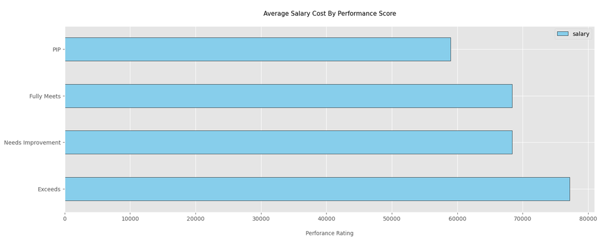

```python
a = pd.DataFrame(df.groupby('performancescore')['salary'].mean().sort_values(ascending = False))
a.plot(kind = 'barh', edgecolor = 'black', color = ['skyblue', 'gold', 'tomato', 'teal', 'navy', 'peachpuff','red'], figsize = (17, 6))
plt.title('\nAverage Salary Cost By Performance Score\n', fontsize = 11)
plt.xlabel('\nPerforance Rating', fontsize = 9.5)
plt.ylabel('')
plt.show()
```

8. How does salary vary by race description?

```python
a = pd.DataFrame(df.groupby('racedesc')['salary'].mean().sort_values(ascending = False))
a.columns = ['Average Salary']
a
```

| racedesc | Average Salary |
| --- | --- |
| Hispanic | 83667.000000 |
| Black or African American | 74431.025000 |
| Asian | 68521.206897 |
| White | 67287.545455 |
| American Indian or Alaska Native | 65806.000000 |
| Two or more races | 59998.181818 |

9. What is the average salary of employees grouped by sex?

```python
a = pd.DataFrame(df.groupby('sex')['salary'].mean().sort_values(ascending = False))
a.columns = ['Average Salary']
a
```

| sex | Average Salary |
| --- | --- |
| M | 70629.400000 |
| F | 67786.727273 |

```python
a = pd.DataFrame(df.groupby('managername')['salary'].mean().sort_values(ascending = False))
a.columns = ['Average Salary']
a
```

| managername | Average Salary |
| --- | --- |
| Board of Directors | 174675.500000 |
| Jennifer Zamora | 136061.142857 |
| Simon Roup | 99331.411765 |
| Brian Champaigne | 98319.750000 |
| Alex Sweetwater | 98203.222222 |
| Janet King | 94814.842105 |
| Peter Monroe | 73578.500000 |
| Debra Houlihan | 69240.000000 |
| John Smith | 65350.428571 |
| Brandon R. LeBlanc | 64818.571429 |
| Lynn Daneault | 64482.538462 |
| Eric Dougall | 63188.750000 |
| Elijiah Gray | 60635.954545 |
| Brannon Miller | 60095.454545 |
| Kelley Spirea | 58912.181818 |
| Michael Albert | 58343.636364 |
| Amy Dunn | 57881.857143 |
| Webster Butler | 57381.238095 |
| Kissy Sullivan | 57183.818182 |
| David Stanley | 56938.571429 |
| Ketsia Liebig | 56936.666667 |

11. What is the average salary of employees with more than 5 years at the company?

```python
five_slr = df[(df['hire_year'] < 2014) & (pd.isna(df['termination_year']))]
five_slr['salary'].mean()
```

```
69834.70192307692
```

12. What is the salary distribution by marital status?

```python
a = pd.DataFrame(df.groupby('maritaldesc')['salary'].mean().sort_values(ascending = False))
a.columns = ['Average Salary']
a
```

| maritaldesc | Average Salary |
| --- | --- |
| Single | 70052.576642 |
| Married | 69827.717742 |
| Widowed | 65195.125000 |
| Divorced | 64427.333333 |
| Separated | 62934.333333 |

13. What is the average salary grouped by termination reason?

```python
a = pd.DataFrame(df.groupby('termreason')['salary'].mean().sort_values(ascending = False))
a.columns = ['Average Salary']
a
```

| termreason | Average Salary |
| --- | --- |
| Learned that he is a gangster | 103613.000000 |
| no-call, no-show | 84460.750000 |
| performance | 78727.750000 |
| hours | 75731.625000 |
| medical issues | 73898.333333 |
| N/A-StillEmployed | 70694.033816 |
| Fatal attraction | 70187.000000 |
| attendance | 67347.428571 |
| Another position | 66116.900000 |
| career change | 65409.444444 |
| maternity leave - did not return | 63800.000000 |
| unhappy | 61348.928571 |
| relocation out of area | 61225.400000 |
| retiring | 60527.750000 |
| military | 59981.750000 |
| more money | 57148.454545 |
| return to school | 55671.000000 |
| gross misconduct | 49773.000000 |

14. How does the average salary vary for employees hired in each year?

```python
a = pd.DataFrame(df.groupby('hire_year')['salary'].mean().sort_values(ascending = False))
a.columns = ['Average Salary']
a
```

| hire_year | Average Salary |
| --- | --- |
| 2017 | 101509.000000 |
| 2010 | 81972.555556 |
| 2009 | 78918.571429 |
| 2016 | 75795.285714 |
| 2015 | 75082.111111 |
| 2012 | 69296.066667 |
| 2014 | 69262.433333 |
| 2013 | 65400.909091 |
| 2006 | 64397.000000 |
| 2011 | 63112.385542 |
| 2008 | 58834.666667 |
| 2007 | 57088.500000 |
| 2018 | 56991.000000 |

15. How does salary vary by the number of special projects?

```python
a = pd.DataFrame(df.groupby('specialprojectscount')['salary'].mean().sort_values(ascending = False))
a.columns = ['Average Salary']
a
```

| specialprojectscount | Average Salary |
| --- | --- |
| 2 | 99351.000000 |
| 7 | 98738.000000 |
| 8 | 96127.000000 |
| 6 | 93252.380952 |
| 5 | 92386.000000 |
| 3 | 90781.666667 |
| 4 | 86401.444444 |
| 1 | 64021.000000 |
| 0 | 62143.514523 |

```python
df3874 = df[df['dayslatelast30'] == 0]
df3874['salary'].mean()
```

```
69534.13309352518
```

```python
a = pd.DataFrame(df.groupby('hire_month')['salary'].mean().sort_values(ascending = False))
a.columns = ['Average Salary']
a
```

| hire_month | Average Salary |
| --- | --- |
| December | 93093.000000 |
| February | 75306.032258 |
| January | 74859.759259 |
| June | 72930.375000 |
| October | 72797.285714 |
| April | 71874.185185 |
| November | 70027.714286 |
| March | 69666.210526 |
| July | 65476.250000 |
| May | 65454.333333 |
| August | 64141.700000 |
| September | 60348.282051 |

## Demographics Analysis

1. What is the count of employees grouped by race and gender?

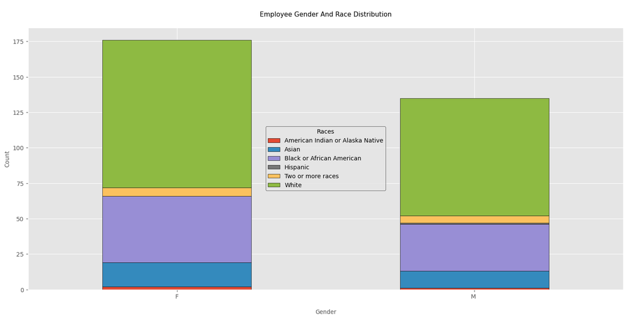

```python
a = df.groupby(['sex', 'racedesc'])['sex'].count().sort_values(ascending = False).unstack()
a.plot(kind = 'bar', stacked = True, edgecolor = 'black', figsize = (18,8))
plt.title('\nEmployee Gender And Race Distribution\n', fontsize = 11)
plt.xlabel('\nGender', fontsize = 9.5)
plt.xticks(rotation = 0)
plt.ylabel('Count', fontsize = 9.5)
plt.legend(loc = 'center', edgecolor = 'black', title = 'Races')
plt.show()
```

2. What is the average age of employees in each department?

```python
df_mar = df[df['birth_year'] < 2005]
df_mar['age'] = 2024 - df_mar['birth_year']
a = pd.DataFrame(df_mar.groupby('department')['age'].mean().sort_values(ascending = False))
a.columns = ['Average Age']
a
```

| department | Average Age |
| --- | --- |
| Production | 43.178218 |
| IT/IS | 42.550000 |
| Software Engineering | 41.200000 |
| Admin Offices | 39.000000 |
| Sales | 38.666667 |

3. How does the average age vary by marital status?

```python
df_mar = df[df['birth_year'] < 2005]
df_mar['age'] = 2024 - df_mar['birth_year']
a = pd.DataFrame(df_mar.groupby('maritaldesc')['age'].mean().sort_values(ascending = False))
a.columns = ['Average Age']
a
```

| maritaldesc | Average Age |
| --- | --- |
| Divorced | 44.611111 |
| Widowed | 44.600000 |
| Single | 42.758065 |
| Separated | 42.250000 |
| Married | 41.272727 |

4. How does employee satisfaction vary by sex and race?

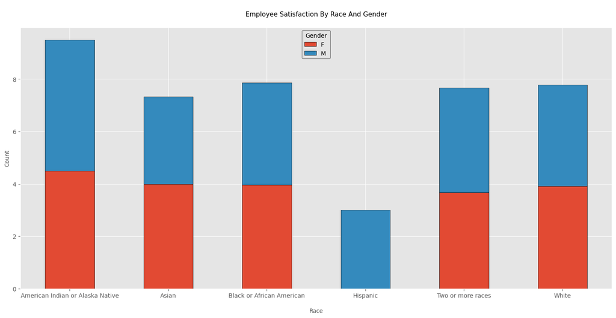

```python
a = pd.DataFrame(df.groupby(['racedesc', 'sex'])['empsatisfaction'].mean().sort_values(ascending = False).unstack())
a.plot(kind = 'bar',edgecolor = 'black', stacked = True, figsize = (18,8))
plt.title('\nEmployee Satisfaction By Race And Gender\n', fontsize = 11)
plt.xlabel('\nRace', fontsize = 9.5)
plt.xticks(rotation = 0)
plt.ylabel('Count', fontsize = 9.5)
plt.legend(loc = 'upper center', edgecolor = 'black', title = 'Gender')
plt.show()
```

5. What is the most common race for each department?

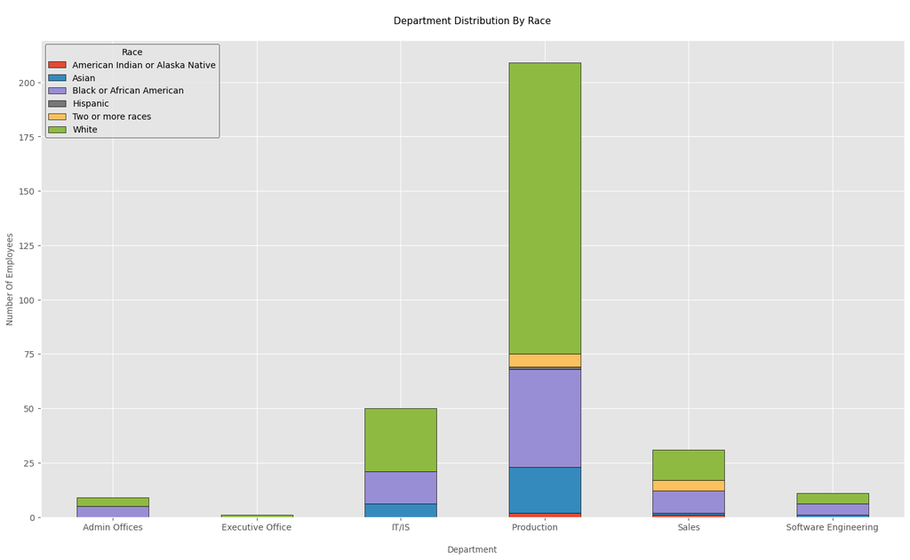

```python
a = pd.DataFrame(df.groupby(['department', 'racedesc'])['racedesc'].count().sort_values(ascending = False).unstack())
a.plot(kind = 'bar',edgecolor = 'black', stacked = True, figsize = (18,10))
plt.title('\nDepartment Distribution By Race\n', fontsize = 11)
plt.xlabel('\nDepartment', fontsize = 9.5)
plt.xticks(rotation = 0)
plt.ylabel('Number Of Employees', fontsize = 9.5)
plt.legend(loc = 'upper left', edgecolor = 'black', title = 'Race')
plt.show()
```

6. What is the engagement survey score grouped by marital status?

```python
df_mar = df[df['birth_year'] < 2005]
a = pd.DataFrame(df_mar.groupby('maritaldesc')['engagementsurvey'].mean().sort_values(ascending = False))
a.columns = ['Average Age']
a
```

| maritaldesc | Average Age |
| --- | --- |
| Widowed | 4.370000 |
| Divorced | 4.193333 |
| Single | 4.185161 |
| Married | 3.967636 |
| Separated | 3.910000 |

7. What is the average satisfaction grouped by department and sex?

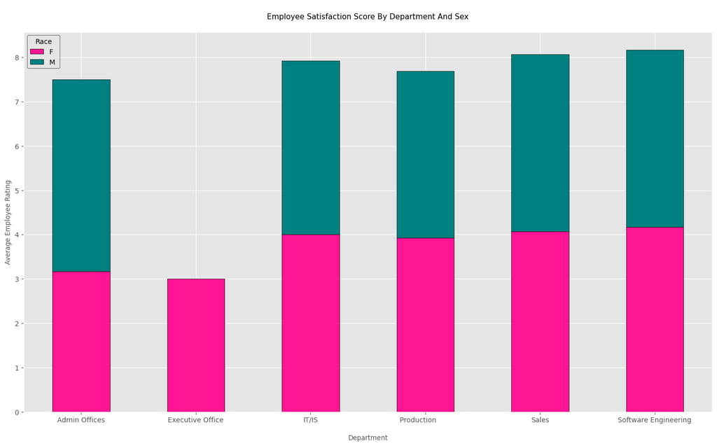

```python
a = pd.DataFrame(df.groupby(['department', 'sex'])['empsatisfaction'].mean().sort_values(ascending = False).unstack())
a.plot(kind = 'bar',edgecolor = 'black', stacked = True, figsize = (18,10), color = ['deeppink', 'teal'])
plt.title('\nEmployee Satisfaction Score By Department And Sex\n', fontsize = 11)
plt.xlabel('\nDepartment', fontsize = 9.5)
plt.xticks(rotation = 0)
plt.ylabel('Average Employee Rating', fontsize = 9.5)
plt.legend(loc = 'upper left', edgecolor = 'black', title = 'Race')
plt.show()
```

[figure not shown]

```python
df_lat = df[df['racedesc'] == 'Hispanic']
plt.figure(figsize = (17, 5))
df['department'].value_counts().plot(kind = 'bar', edgecolor = 'black', color = ['gold', 'deeppink', 'darkorchid', 'teal', 'orange'])
plt.title('\nHispanic/Latino Distribution By Department\n', fontsize = 11)
plt.xlabel('\nDepartment', fontsize = 11)
plt.xticks(rotation = 0)
plt.ylabel('Count of Employees in Department', fontsize = 9.5)
plt.show()
```